# Group 3: Prediction of Online Engagement for Tweets

## Introduction

- **Introduction**: Twitter is a potent platform for information dissemination and social interaction, making it a critical tool for individuals, brands, and organizations seeking to influence, inform, or engage with a broad audience. By predicting the engagement of Twitter, we can see how best each tweet performs, the sentiment around tweet, the various topics discussed as well as the most important/influencial topics etc.

  The primary goal of this project is to predict Twitter engagement based on the text of tweets. By analyzing the text, we can be able to extract additional features which can be used to predict the level of engagement; which we take as the sum of the likes and retweets for each user.

## Data Overview

  Initial inspection revealed that some tweet texts were contextually ambiguous or seemed incomplete. To address this, a detailed content analysis was performed. This exploration focused on identifying key themes, topics, and sentiments within the tweets, which are crucial for understanding the factors that drive engagement.

  Moreover, the consistency of data across the Retweets and Likes metrics suggests potential patterns of user engagement that could be explored for predictive insights. The Timestamp data also offers an opportunity to examine how engagement varies over time, possibly relating to daily or weekly activity cycles on Twitter.

  This enriched data overview not only confirms the dataset’s readiness for further analysis but also guides our subsequent exploratory and predictive efforts. By delving into the nuances of tweet content and engagement trends, we aim to uncover actionable insights that could inform effective Twitter strategies.

## Data Preprocessing

- **Text Preprocessing Steps**: The following steps were applied for the preprocessing of the data. Normalization and Cleaning:
- *Lowercasing*: All the text was converted to lower case to unify the format.
- *URL and Special Character Removal*: We employed regular expressions to eliminate URLs and non-alphabetic characters, focusing analysis purely on textual content.
- *Tokenization and Stopword Removal*: The text feature was split into individual words using NLTK’s word_tokenize. After which the common enlish stop words were filtered using NLTK to focus on more meaningful words in the text.

## Exploratory Data Analysis (EDA)

Here’s the plot showing the top 20 most frequent words in tweets:

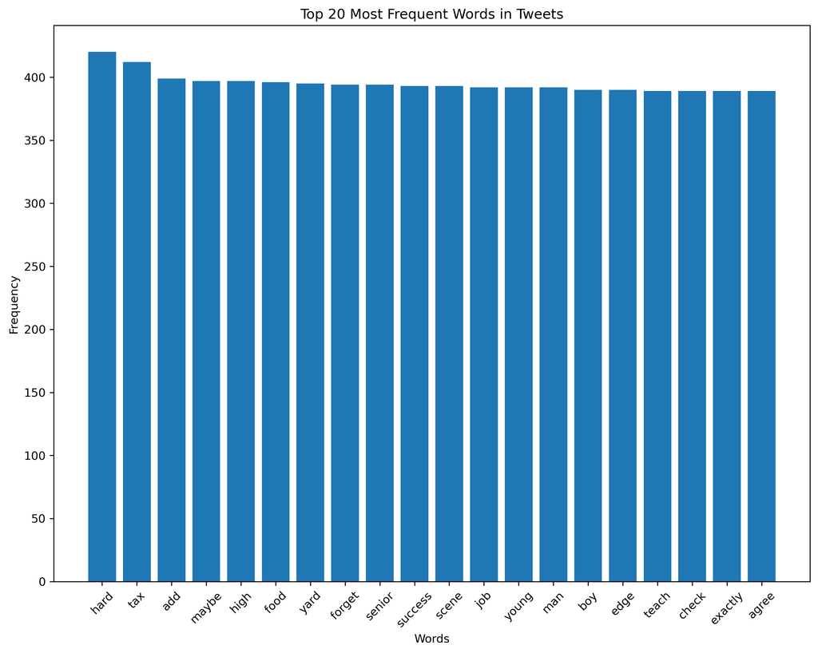

Top 20 Most Frequent Words in Tweets

### Engagement Metrics Analysis

The visualizations below represent the average likes and retweets by hour of day and day of week. These insights can help understand peak times for engagement on Twitter.

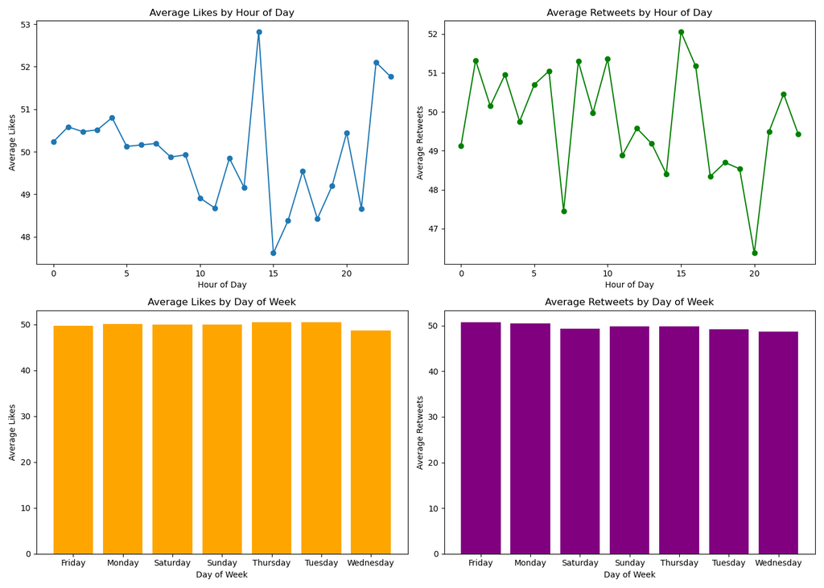

Engagement Metrics

### Analysis of Engagement by Readability Score

The following plots illustrate how engagement metrics such as likes and retweets vary with different readability scores. This can help understand which content is more engaging based on its readability.

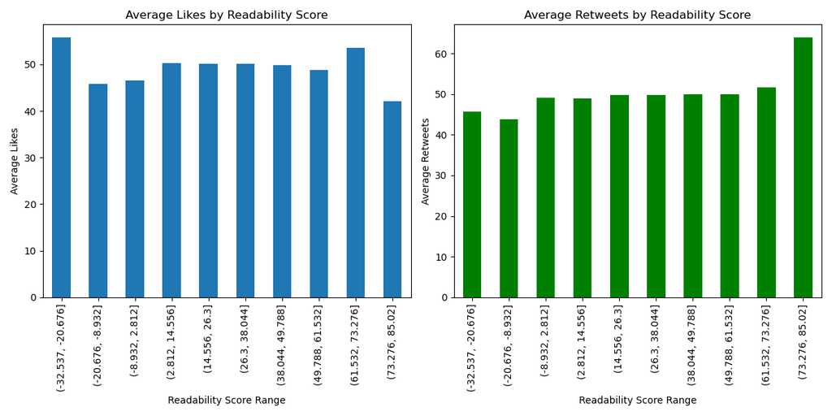

Engagement by Readability Score

### Engagement Analysis by Text Length

The following visualization shows how engagement metrics such as likes and retweets vary with text characteristics including word length and sentence length. This analysis can help understand what text features correlate with higher engagement.

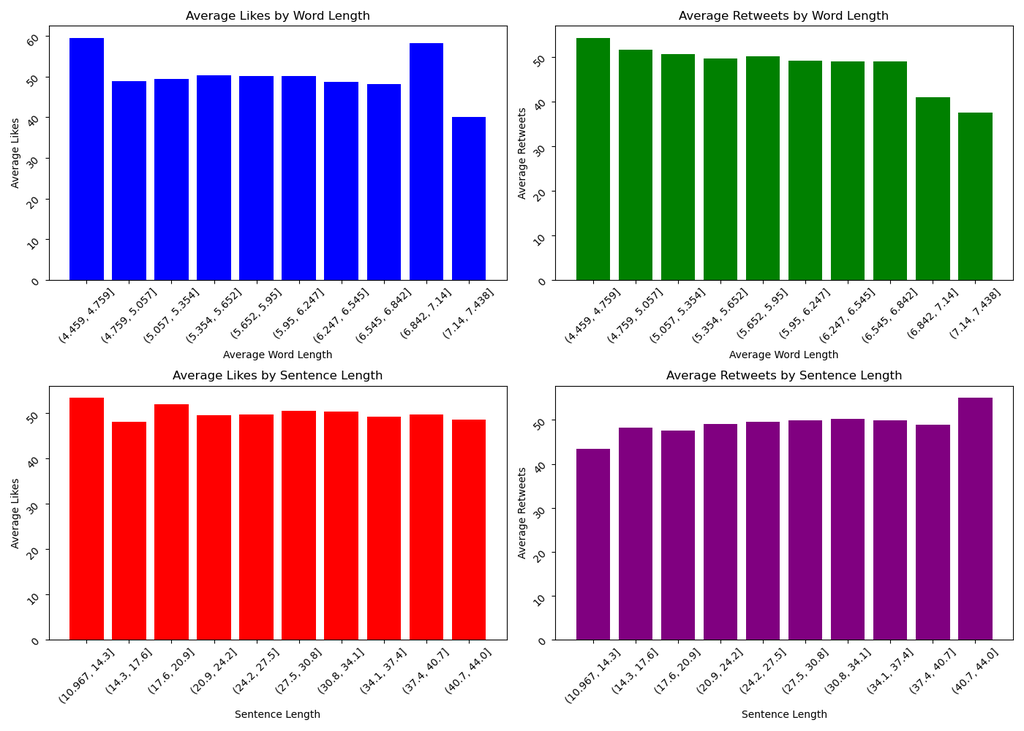

Engagement Analysis by Text Length

### Engagement Analysis by Topic

The following visualization shows how engagement metrics such as likes and retweets are distributed across different dominant topics. This analysis can help identify topics that generate higher engagement on social media platforms.

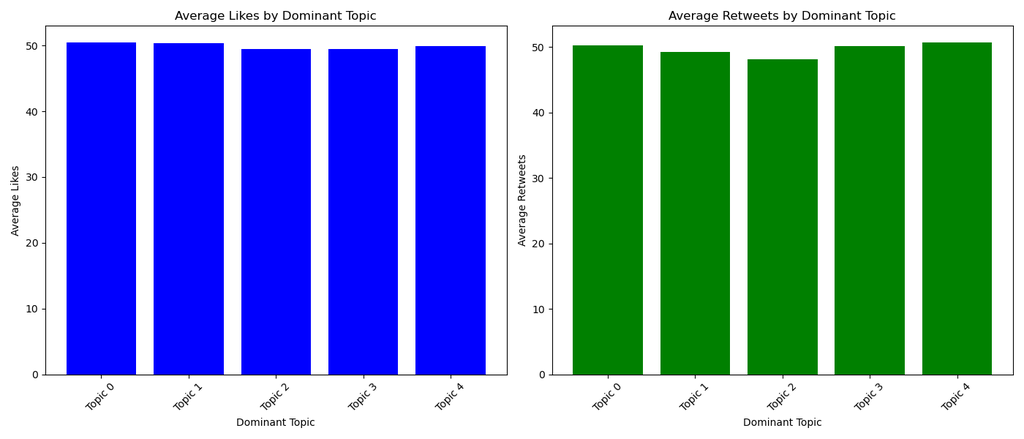

Engagement Analysis by Topic

### Monthly Engagement Analysis

The visualizations below represent the trends in average likes and retweets per month. Analyzing these trends helps understand engagement patterns over time, highlighting peak periods of user interaction.

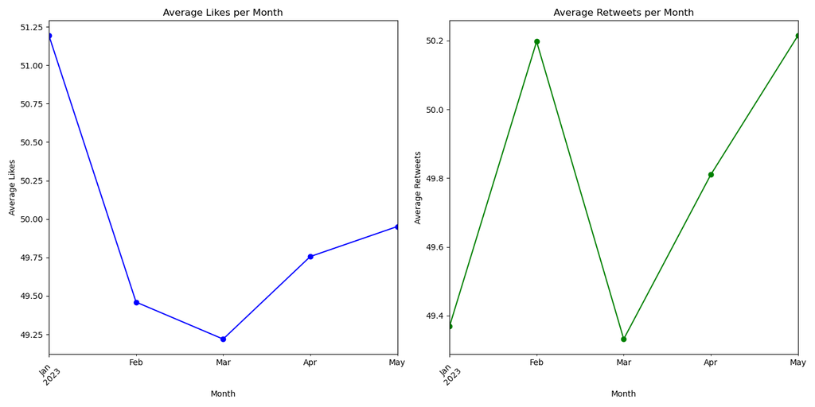

Monthly Engagement Trends

### Sentiment and Engagement Analysis Over Time

The visualizations below illustrate the monthly trends in average sentiment and engagement metrics such as likes and retweets. This comprehensive analysis helps in understanding how sentiment correlates with user engagement over time.

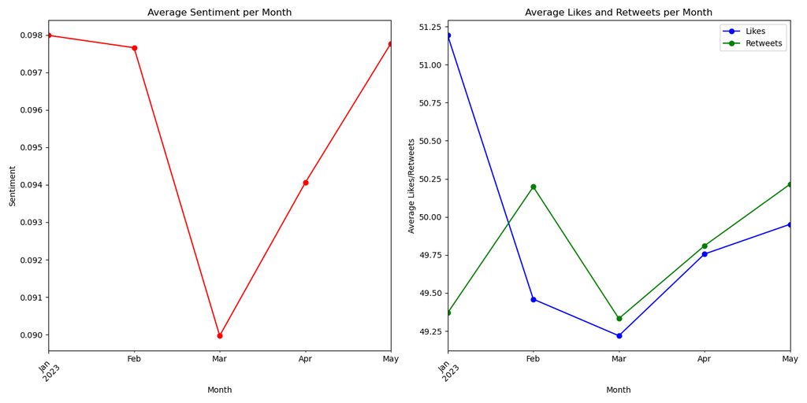

Sentiment and Engagement Over Time

## Feature Extraction

- **Feature Creation**: We engineered several features from the existing data to enhance our predictive modeling capabilities:
- *TF-IDF Vectorization*: Finally, we transformed cleaned text into a numerical format using TfidfVectorizer, limiting to the top 100 most relevant terms. This method highlights the importance of words relative to the document corpus, ideal for predictive modeling.
- *Sentiment Analysis*: We utilized TextBlob to compute the sentiment polarity of tweets, providing insights into the emotional tone of the content.
- *Temporal Features*: Next, the time based attributes were extracted such as hour_of_day, day_of_week, and month from the Timestamp. These features help analyze engagement patterns over different times and days.
- *Readability Scores*: We the applied textstat to calculate the Flesch reading ease score for each tweet, offering a measure of text complexity which might correlate with engagement.
- *Text Length Metrics*: After this, we calculated the average word length and sentence_length to assess the complexity and size of tweets.
- *Named Entity Recognition*: We Leveraged spaCy to extract named entities, adding depth to our textual analysis by identifying significant people, organizations, or locations mentioned in tweets.
- *LDA Topics* : Then, we implemented Latent Dirichlet Allocation via scikit-learn to identify dominant topics within the tweet corpus, allowing us to explore thematic patterns in engagement.
- *Presence of Mentions, Hashtags, and URLs*: Binary indicators were created to signify the presence of mentions, hashtags, and URLs within tweets, which are often critical factors in engagement dynamics.

## Modeling

- **Feature Selection**: For our predictive model, we focused on a set of features believed to significantly impact Twitter engagement. These included:
- *Textual features*: sentiment, readability_score, avg_word_length, sentence_length.
- *Temporal features*: hour_of_day, day_of_week, month.
- *Social indicators*: has_mentions, has_hashtags, contains_link. These features were chosen based on their potential to influence user interaction and engagement with tweets, as demonstrated during our exploratory data analysis phase
- **Model Choices**: We tested a variety of models to address the regression nature of our target variable, Total_engagement. Our model selection included:
- *Linear Models*: Linear Regression, Ridge Regression, and Lasso Regression. These were chosen for their ability to provide baseline performance and interpretability.
- *Ensemble Methods*: RandomForestRegressor and GradientBoostingRegressor. These models were selected for their robustness and ability to handle non-linear relationships within the data effectively.
- ***Performance Evaluation**: Model performance was assessed using Root Mean Squared Error (RMSE) and Mean Absolute Error (MAE) across a 5-fold cross-validation:

## Results and Interpretation

The cross-validation results for RMSE and MAE are as follows:

- *RMSE Results*: Linear Regression: 41.37 Ridge Regression: 41.37 Lasso Regression: 41.32 Random Forest: 42.62 Gradient Boosting: 41.50
- *MAE Results*: Linear Regression: 33.90 Ridge Regression: 33.90 Lasso Regression: 33.85 Random Forest: 34.90 Gradient Boosting: 33.98

  From these results, it appears that Lasso Regression slightly outperforms other linear models in both RMSE and MAE, suggesting it effectively regularizes and simplifies the model without significant loss in accuracy. Surprisingly, RandomForest, typically robust, performed slightly worse, indicating potential overfitting or inadequate parameter tuning. Gradient Boosting also shows competitive results, closely following the performance of Lasso Regression.

  These insights highlight the complexity of modeling tweet engagement and underscore the importance of further model tuning and validation, especially for the ensemble methods that might capture more subtle data patterns not easily modeled by linear approaches.

## Areas of Improvement

```
For future improvement, we have highlighted the following areas where we could do better;
```

- Expanding the dataset through additional data collection to help improve the robustness of the models. A more diverse data would provide better insights and we can also create more meaningful features which will better help our models.
- Exploring other alternative machine learning techniques such as deep learning models and neural networks which would be useful for exploring non-linear behaviours.
- Explore other techniques such as Setfit ABSA for aspect based sentiment analysis such as the, word embeddings etc.